# **Spectral Clustering Tutorial**

Gargee Jagtap, Sarah Saas, David Siamon, Nadir Siddiqui

DS 6030 | Fall 2022 | University of Virginia

# Table of Contents

### Introduction

### Mathematical Methods

#### i. Similarity Graph

#### ii. Laplacian Matrix

#### iii. Eigendecomposition

#### iv. Create Clusters

### Spectral Coding Clustering Examples

#### i. Using R

#### ii. Using Python

### Applications

### Conclusion

### References

# Introduction

Clustering is a type of unsupervised learning algorithm that allows data points to be grouped into “clusters”. These clusters group data points into these clusters so that all data points in the cluster are similar in some way and dissimilar to the points in the other clusters. Clustering is useful because it has predictive power and objects can be grouped which is useful for naming them for communication. There are several common forms of clustering including; k-means, mean-shift, density-based spatial clustering of applications with noise (DBSCAN), expectation maximum (EM), and spectral clustering. This tutorial will focus on spectral clustering.

Spectral clustering is a popular clustering technique due to its ease of implementation and its ability to outperform other methods (such as the k-means algorithm). It makes no assumptions about the shape of the clusters and can use non-graphical data. Spectral clustering uses graph theory to use the edges to determine communities of nodes. This technique also differs from k-means and common algorithms because it uses connectivity instead of compactness like most algorithms. Compactness uses the distance between points to group them, meaning points closest together will be grouped. This often means that points are clustered around a geographic center.

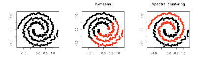

When using connectivity, like in spectral clustering, points may be close together but not in the same cluster. This means that points can result in clusters that are shaped like spirals or wandering lines. On the other hand, since spectral clustering uses connectivity, it is computationally more expensive compared to other methods. Meaning this method should be used for small datasets with high dimensionality compared to large datasets with many observations. In addition to being computationally taxing, larger datasets also tend to decrease the accuracy of clustering in spectral clustering.

# Mathematical Methods

We should define some basic graph theory terms. A graph $G = (V, E)$ consists of a set of vertices (nodes), and edges which connect the nodes. We can define our vertex set $V = \{v_1, …, v_n\}$, so each $v_i$ represents a data point, or node $(\forall i \in 1,\dots , n)$. Let’s look at the following graph as an example:

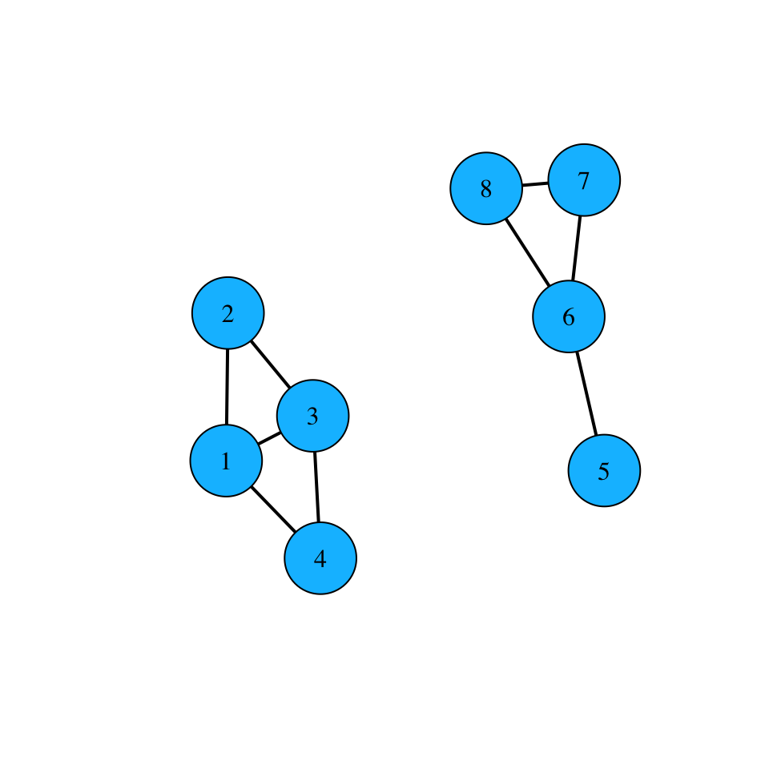

Our graph has 8 vertices and 9 edges. In this case, the edges are undirected and have no weights associated with them. Two nodes are adjacent if they are connected by an edge. The neighborhood of a vertex is the set of vertices that are adjacent to it. So, the neighborhood of vertex 1 is $\{2,3,4\}$, the neighborhood of vertex 7 is $\{6,8\}$. The degree of a vertex is how many edges are incident (connected) to it. Since our graph is undirected, we can assume the in-degree equals the out-degree. In this example, the degree of each vertex in-order is: $\{3,2,3,2,1,3,2,2\}$. We can construct a degree matrix where we have a row and column for each vertex, and the degree of each node is on the diagonal while the off-diagonals are zero. Another way to represent this graph is through an adjacency matrix. Adjacency matrices have rows and columns for each node and indicate if an edge is incident between two nodes (1 if yes, 0 if no). If our edges had weights, we would replace the 1 with the corresponding weight. The degree and adjacency matrix for this graph are as shown below, respectively:

$$\begin{equation}
\begin{bmatrix}
3 & 0 & 0 & 0 & 0 & 0 & 0 & 0 \\
0 & 2 & 0 & 0 & 0 & 0 & 0 & 0 \\
0 & 0 & 3 & 0 & 0 & 0 & 0 & 0 \\
0 & 0 & 0 & 2 & 0 & 0 & 0 & 0 \\
0 & 0 & 0 & 0 & 1 & 0 & 0 & 0 \\
0 & 0 & 0 & 0 & 0 & 3 & 0 & 0 \\
0 & 0 & 0 & 0 & 0 & 0 & 2 & 0 \\
0 & 0 & 0 & 0 & 0 & 0 & 0 & 2
\end{bmatrix}
\hspace{1cm}
\begin{bmatrix}
0 & 1 & 1 & 1 & 0 & 0 & 0 & 0 \\
1 & 0 & 1 & 0 & 0 & 0 & 0 & 0 \\
1 & 1 & 0 & 1 & 0 & 0 & 0 & 0 \\
1 & 0 & 1 & 0 & 0 & 0 & 0 & 0 \\
0 & 0 & 0 & 0 & 0 & 1 & 0 & 0 \\
0 & 0 & 0 & 0 & 1 & 0 & 1 & 1 \\
0 & 0 & 0 & 0 & 0 & 1 & 0 & 1 \\
0 & 0 & 0 & 0 & 0 & 1 & 1 & 0
\end{bmatrix}
\end{equation}$$

Now we can begin our spectral clustering process. The algorithm can be outlined in four key steps:

I. Generate a similarity graph  
II. Compute the Laplacian Matrix  
III. Eigendecomposition  
IV. Create clusters

### I Similarity Graph

We start by computing a similarity graph $G = G(V, E)$. Let’s assume our graph is undirected. We can represent this graph through an adjacency matrix composed of the similarities between nodes.

Computing the distance between two points is more intuitive for some problems than others. If we have a simple 2-D dataset with distance values on each axis, we can use the Euclidian distance formula $\sqrt{x^{2}+y^{2}}$. However, for datasets with higher dimensionality, the distance between two points isn’t as intuitive. Fortunately, the Euclidian distance formula has a dimension-generic version: $dist(x,y)=\sqrt{\sum_{i} (y_i-x_i)}$. We can apply this to numeric data of any dimension to compute the distance between two points.

We use the Euclidian distance formula when constructing our similarity matrix S. The formula for an entry in S is as follows:

$$\begin{equation}
s(x_i,x_j) = \text{exp} \left (-\frac{||x_i-x_j||^2}{2\sigma^2} \right )
\end{equation}$$

Where $x_i$ and $x_j$ are the two data points, $||x_i-x_j||$ is their Euclidian distance, and sigma $\sigma$ is a scaling constant to control for the width of the neighborhoods. For our example, since our edges aren’t weighted, we will assume the similarity matrix is the same as the adjacency matrix.

### II Laplacian Matrix

The next step is to compute the Laplacian Matrix, which we’ll then perform eigendecomposition on. The motivation behind this is that the Laplacian reduces the dimensionality of our data, such that observations in the same cluster will be close to each other, while observations in different clusters will not.

The Laplacian matrix $L$ is computed by taking the difference of the degree matrix $D$ and the similarity matrix $S$. To calculate the degree $d(x)$ of our observations, we use the following formula:

$$\begin{equation}
d_i = \sum_{j|(i,j) \in E} w_{ij}
\end{equation}$$

This formula differs from the one introduced above, because we are now dealing with weighted edges. Rather than simply computing the number of edges a node has, we now take the sum of the weights on all the edges. Our matrix $D$ is the values of $d(x)$ along the diagonal, with all non-diagonal values set to 0.Once $D$ is computed, we use it along with $S$: $L = D – S$.

The Laplacian matrix for our working example is given below:

$$\begin{equation}
\begin{bmatrix}
3 & -1 & -1 & -1 & 0 & 0 & 0 & 0 \\
-1 & 2 & -1 & 0 & 0 & 0 & 0 & 0 \\
-1 & -1 & 3 & -1 & 0 & 0 & 0 & 0 \\
-1 & 0 & -1 & 2 & 0 & 0 & 0 & 0 \\
0 & 0 & 0 & 0 & 1 & -1 & 0 & 0 \\
0 & 0 & 0 & 0 & -1 & 3 & -1 & -1 \\
0 & 0 & 0 & 0 & 0 & -1 & 2 & -1 \\
0 & 0 & 0 & 0 & 0 & -1 & -1 & 2
\end{bmatrix}
\end{equation}$$

### III Eigendecomposition

Now we can obtain the eigenvectors and eigenvalues of the Laplacian matrix. Given our matrix $L$, we can define an eigenvector $x$ and its corresponding eigenvalue $\lambda$ as any pair which satisfies the following:

$$\begin{equation}
Lx = \lambda x
\end{equation}$$

This is known as eigendecomposition. For large matrices, these values are not computable by hand. That’s why we use computers! Further below we’ll see an example of eigendecomposition performed on a large matrix.

Let’s go back to our working example. Keep in mind our graph consists of 8 vertices, therefore we will have 8 eigenvalues and 8 eigenvectors. The results of our eigendecomposition are shown below:

$$\begin{equation}
\begin{bmatrix}
1 & 0 & 0 & 0 & 0 & -1 & -2 & 0 \\
1 & 0 & 0 & -1 & 0 & 0 & 1 & 0 \\
1 & 0 & 0 & 0 & 0 & 1 & 0 & 0 \\
1 & 0 & 0 & 1 & 0 & 0 & 1 & 0 \\
0 & 1 & -2 & 0 & 0 & 0 & 0 & 1 \\
0 & 1 & 0 & 0 & 0 & 0 & 0 & -3 \\
0 & 1 & 1 & 0 & -1 & 0 & 0 & 1 \\
0 & 1 & 1 & 0 & 1 & 0 & 0 & 1
\end{bmatrix}
\end{equation}$$

Each eigenvector is a column, corresponding to an eigenvalue. Our eigenvalues for our working example are: $\{0, 0, 1, 2, 3, 4, 4, 4\}$. Since our graph has two connected components, we have two eigenvalues equal to zero, the rest non-zero. If we wanted our graph to have k clusters $(k>2)$, we would simply normalize our Laplacian matrix by $L_{norm} = D^{½}LD^{½}$ and redo the above steps.

### IV Create clusters

Now the fun part! We have a set of eigenvectors, sorted by their corresponding eigenvalue in non-decreasing order. Suppose we’ve decided we want $k=4$ clusters. We would then select the first four eigenvectors and put them through a clustering algorithm such as K-Means, which would output our cluster assignments! Below is the output when running K-means for the first four eigenvectors of our example: $\{0, 1, 1, 0, 3, 2, 2, 2\}$

And as a visual:

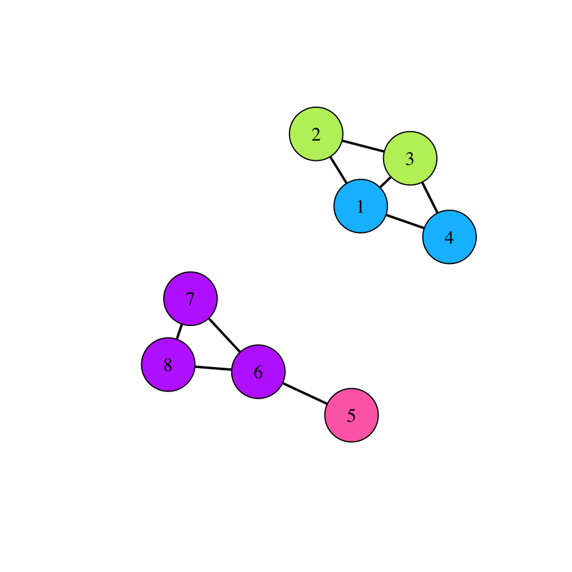

Note the graph has been subdivided into 4 sections, with nodes 1 and 3 arbitrarily assigned to one of their connected sections.

# Spectral Clustering Coding Examples

## Using R

By this point we have laid the foundation for spectral clustering, but our working example wasn’t really that complicated. Let’s look at how to implement spectral clustering and compare the results to a k-means approach.

```r
## Packages
library(tidyverse)
library(gridExtra)
library(ggplot2)
```

We first need to generate some data for clustering. We will generate three circular, uniform distributions and plot them:

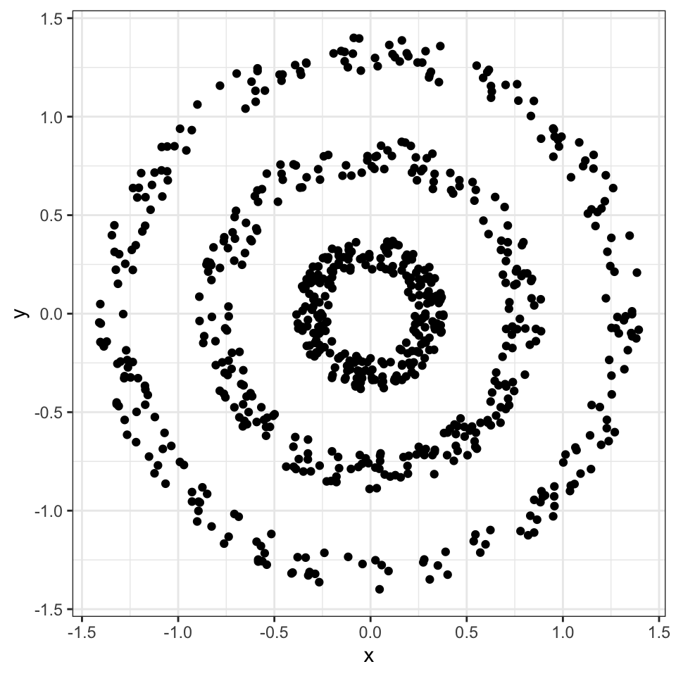

```r
# Generate circular uniform distributions of data
set.seed(1748)

## Set min and max parameters for each distribution
min_vals <- c(0.05, 0.5, 1.5)
max_vals <- c(0.15, 0.8, 2.0)
x <- c()
y <- c()

## Generate distributions using parameters
for(i in 1:3){
  r <- sqrt(runif(250, min = min_vals[i], max = max_vals[i]))
  p <- runif(250)
  theta <- p * 2 * pi
  x_temp <- r * cos(theta)
  y_temp <- r * sin(theta)
  x <- c(x, x_temp)
  y <- c(y, y_temp)
}

## Create data frame
data <- as.data.frame(cbind(x, y))

## Plot coordinates
ggplot(data=data, aes(x=x, y=y)) + geom_point()
```

Our goal is to cluster the data. By sight, there are clearly three rings representing the three distributions of data. We will cluster the data using k-means first:

```r
# Kmeans Application
set.seed(1748)

## Run Kmeans algorithm with 3 clusters
km <- kmeans(data, 3)


## Retrieve and store cluster assignments
kmeans_clusters <- km$cluster
kmeans_results <- cbind(data, cluster = as.factor(kmeans_clusters))
head(kmeans_results)
```

```
#>            x        y cluster
#> 1  0.2683618 -0.02650       3
#> 2  0.3785791 -0.01143       3
#> 3  0.0001506 -0.22683       3
#> 4 -0.2894358 -0.14824       1
#> 5  0.0990622  0.22379       2
#> 6 -0.1655848  0.25820       2
```

The output above represents the cluster each point is assigned to using k-means. We will now calculate the cluster assignments using spectral clustering:

```r
# Spectral Clustering

## Create Similarity matrix of Euclidean distance between points
S <- as.matrix(dist(data))


## Create Degree matrix
D <- matrix(0, nrow=nrow(data), ncol = nrow(data)) # empty nxn matrix

for (i in 1:nrow(data)) {

      # Find top 10 nearest neighbors using Euclidean distance
      index <- order(S[i,])[2:11]

      # Assign value to neighbors
      D[i,][index] <- 1
}

# find mutual neighbors
D = D + t(D)
D[ D == 2 ] = 1

# find degrees of vertices
degrees = colSums(D)
n = nrow(D)


## Compute Laplacian matrix
# Since k > 2 clusters (3), we normalize the Laplacian matrix:
laplacian = ( diag(n) - diag(degrees^(-1/2)) %*% D %*% diag(degrees^(-1/2)) )


## Compute eigenvectors
eigenvectors = eigen(laplacian, symmetric = TRUE)
n = nrow(laplacian)
eigenvectors = eigenvectors$vectors[,(n - 2):(n - 1)]


set.seed(1748)
## Run Kmeans on eigenvectors
sc = kmeans(eigenvectors, 3)


## Pull clustering results
sc_results = cbind(data, cluster = as.factor(sc$cluster))
head(sc_results)
```

```
#>            x        y cluster
#> 1  0.2683618 -0.02650       1
#> 2  0.3785791 -0.01143       1
#> 3  0.0001506 -0.22683       1
#> 4 -0.2894358 -0.14824       1
#> 5  0.0990622  0.22379       1
#> 6 -0.1655848  0.25820       1
```

The output above represents the cluster each point is assigned to using spectral clustering. Let’s now graph the data and use colors to represent the cluster assignment of both k-means and spectral clustering:

```r
# Kmeans plot
kmeans_plot = ggplot(data = kmeans_results, aes(x=x, y=y, color = cluster)) +
  geom_point() +
  scale_color_manual(values = c('1' = "violetred2",
                                '2' ="darkorchid2",
                                '3' ="darkolivegreen2")) +
  ggtitle("K-Means Clustering") +
  theme(panel.grid.major = element_blank(), panel.grid.minor = element_blank(),
        panel.background = element_blank(), axis.line = element_line(colour = "black"),
        plot.title = element_text(hjust = 0.5), legend.position="bottom")
```

[output not shown]

```r
# Spectral Clustering plot
sc_plot = ggplot(data = sc_results, aes(x=x, y=y, color = cluster)) +
  geom_point() +
  scale_color_manual(values = c('1' = "violetred2",
                                '2' ="darkorchid2",
                                '3' ="darkolivegreen2")) +
  ggtitle("Spectral Clustering") +
  theme(panel.grid.major = element_blank(), panel.grid.minor = element_blank(),
        panel.background = element_blank(), axis.line = element_line(colour = "black"),
        plot.title = element_text(hjust = 0.5), legend.position="bottom")
```

[output not shown]

```r
# Arrange plots
grid.arrange(kmeans_plot, sc_plot, nrow=1)
```

[output not shown]